# TRABAJO FINAL

2025-11-21

```r
rm(list = ls())
library(rio)

linkToData <- "https://raw.githubusercontent.com/valentinabarboza/Entrega-2/main/data_final.xls"

DATA <- import(linkToData)
str(DATA)
```

```
## 'data.frame':    171 obs. of  8 variables:
##  $ Country                  : chr  "Afghanistan" "Albania" "Algeria" "Angola" ...
##  $ Country Code             : chr  "AFG" "ALB" "DZA" "AGO" ...
##  $ Year                     : num  2023 2023 2023 2023 2023 ...
##  $ World Population         : num  41454761 2745972 46164219 36749906 45538401 ...
##  $ Income group             : chr  "Países de ingreso bajo" "Ingreso mediano alto" "Ingreso mediano alto" "Países de ingreso mediano bajo" ...
##  $ Electoral Democracy Index: num  0.073 0.507 0.265 0.33 0.838 0.635 0.855 0.846 0.187 0.124 ...
##  $ CPI SCORE                : num  20 37 36 33 37 47 75 71 23 42 ...
##  $ kilos_totales            : chr  "4558807.9807500001" "2357.9850499999998" "50045.629073999997" "13993.338" ...
```

```r
library(dplyr)
DATA <- DATA %>%
  rename(democracia = 'Electoral Democracy Index')
```

```r
DATA <- DATA %>%
  rename(poblacion = 'World Population')
```

```r
DATA <- DATA %>%
  rename(corrupcion = 'CPI SCORE')
```

```r
DATA <- DATA %>%
  rename(Ningresos = 'Income group')
```

```r
DATA$kilos_totales <- as.numeric(DATA$kilos_totales)
```

#variable dependiente

```r
# Descripción estadística de la variable dependiente
vd_desc <- data.frame(
  Variable = "Kilos totales incautados (kg)",
  N       = sum(!is.na(DATA$kilos_totales)),
  Min     = min(DATA$kilos_totales, na.rm = TRUE),
  Q1      = as.numeric(quantile(DATA$kilos_totales, 0.25, na.rm = TRUE)),  # sin "25%"
  Mediana = median(DATA$kilos_totales, na.rm = TRUE),
  Media   = mean(DATA$kilos_totales, na.rm = TRUE),
  Q3      = as.numeric(quantile(DATA$kilos_totales, 0.75, na.rm = TRUE)),  # sin "75%"
  Max     = max(DATA$kilos_totales, na.rm = TRUE),
  SD      = sd(DATA$kilos_totales, na.rm = TRUE)
)

knitr::kable(
  vd_desc,
  digits = 2,
  row.names = FALSE,   # <-- esto oculta cualquier nombre de fila
  caption = "Descripción estadística de la variable dependiente"
)
```

Descripción estadística de la variable dependiente

| Variable | N | Min | Q1 | Mediana | Media | Q3 | Max | SD |
| --- | --- | --- | --- | --- | --- | --- | --- | --- |
| Kilos totales incautados (kg) | 115 | 0.03 | 1338.12 | 13413.29 | 349148.6 | 124796.6 | 9151002 | 1292942 |

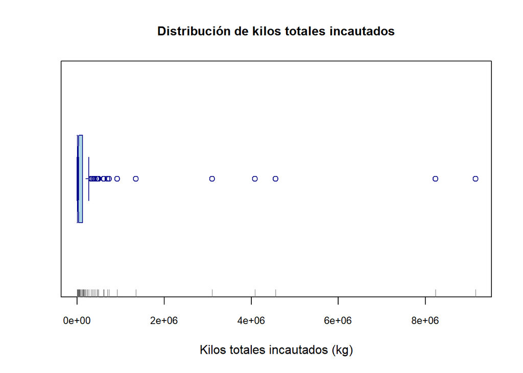

```r
boxplot(
  DATA$kilos_totales,
  horizontal = TRUE,
  main = "Distribución de kilos totales incautados",
  xlab = "Kilos totales incautados (kg)",
  col = "lightblue",      # color de la caja
  border = "darkblue",    # color del borde
  notch = TRUE,           # caja con hendidura
  outline = TRUE,         # mostrar atípicos
  cex.axis = 0.8,
  cex.main = 1
)
# Opción: agregar puntos tipo rug para ver densidad en el eje
rug(DATA$kilos_totales, col = "gray40")
```

#Interpretación La variable dependiente kilos_totales presenta una distribución altamente asimétrica a la derecha: la mayoría de países tiene cantidades relativamente bajas de incautación, pero el boxplot muestra varios valores atípicos con incautaciones muy elevadas, lo que revela una dispersión considerable entre países.

#Variable independiente: Ningresos

```r
# Descripción estadística de la variable Ningresos

freq_ning <- table(DATA$Ningresos)                     # frecuencias
prop_ning <- prop.table(freq_ning) * 100               # porcentajes

ning_desc <- data.frame(
  Nivel_ingreso = names(freq_ning),
  Frecuencia    = as.vector(freq_ning),
  Porcentaje    = round(as.vector(prop_ning), 1))
knitr::kable(
  ning_desc,
  caption = "Distribución de la variable Ningresos",
  digits = 1)
```

Distribución de la variable Ningresos

| Nivel_ingreso | Frecuencia | Porcentaje |
| --- | --- | --- |
| Ingreso alto | 55 | 32.2 |
| Ingreso mediano alto | 45 | 26.3 |
| No clasificado | 2 | 1.2 |
| Países de ingreso bajo | 24 | 14.0 |
| Países de ingreso mediano bajo | 45 | 26.3 |

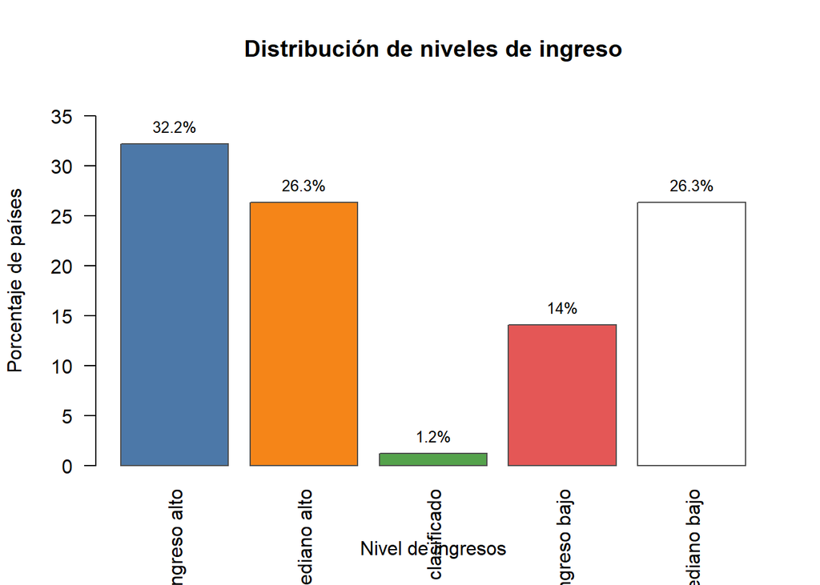

```r
# Frecuencias y porcentajes
freq_ning <- table(DATA$Ningresos)
prop_ning <- prop.table(freq_ning) * 100

# Paleta de colores (puedes cambiarla)
colores <- c("#4C78A8", "#F58518", "#54A24B", "#E45756")

# Gráfico de barras bonito
bp <- barplot(
  prop_ning,
  main = "Distribución de niveles de ingreso",
  ylab = "Porcentaje de países",
  xlab = "Nivel de ingresos",
  las  = 2,             # etiquetas del eje X en vertical
  col  = colores[seq_along(prop_ning)],  # un color por barra
  border = "gray30",
  ylim = c(0, max(prop_ning) * 1.15)     # deja espacio para los textos
)

# Agregar el porcentaje encima de cada barra
text(
  x = bp,
  y = prop_ning,
  labels = paste0(round(prop_ning, 1), "%"),
  pos = 3,    # encima de la barra
  cex = 0.8
)
```

#Interpretación La variable Ningresos muestra una distribución relativamente equilibrada, pero con mayor presencia de países de ingreso alto, que representan alrededor de un tercio de la muestra. Les siguen los países de ingreso mediano alto y ingreso mediano bajo, con proporciones también importantes. En cambio, los países de ingreso bajo constituyen una fracción menor del total, mientras que la categoría “no clasificado” prácticamente no aparece. En conjunto, la muestra está algo sesgada hacia países de ingresos medios y altos, lo que es importante tener en cuenta al interpretar los resultados del modelo.

#Variable independiente: democracia

```r
dem_desc <- data.frame(
  Variable = "Índice de democracia",
  N       = sum(!is.na(DATA$democracia)),
  Min     = min(DATA$democracia, na.rm = TRUE),
  Q1      = as.numeric(quantile(DATA$democracia, 0.25, na.rm = TRUE)),  # sin "25%"
  Mediana = median(DATA$democracia, na.rm = TRUE),
  Media   = mean(DATA$democracia, na.rm = TRUE),
  Q3      = as.numeric(quantile(DATA$democracia, 0.75, na.rm = TRUE)),  # sin "75%"
  Max     = max(DATA$democracia, na.rm = TRUE),
  SD      = sd(DATA$democracia, na.rm = TRUE)
)

knitr::kable(
  dem_desc,
  digits = 2,
  row.names = FALSE,   # <- oculta nombres de fila
  caption = "Descripción estadística de la variable democracia"
)
```

Descripción estadística de la variable democracia

| Variable | N | Min | Q1 | Mediana | Media | Q3 | Max | SD |
| --- | --- | --- | --- | --- | --- | --- | --- | --- |
| Índice de democracia | 171 | 0.01 | 0.26 | 0.51 | 0.5 | 0.74 | 0.92 | 0.26 |

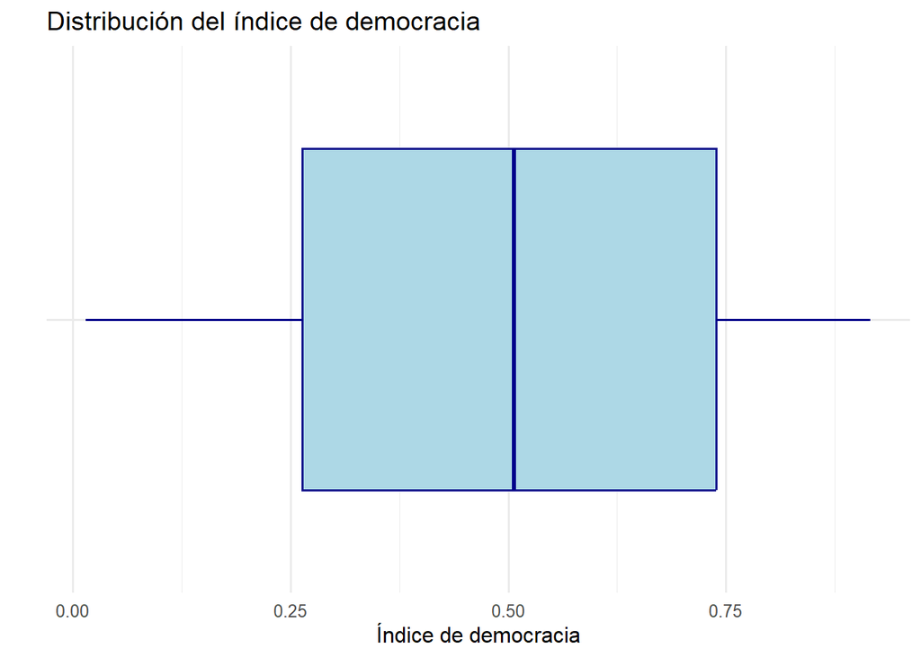

```r
library(ggplot2)

ggplot(DATA, aes(x = "", y = democracia)) +
  geom_boxplot(
    fill = "lightblue",
    color = "darkblue",
    outlier.color = "red",
    outlier.alpha = 0.6
  ) +
  coord_flip() +
  labs(
    title = "Distribución del índice de democracia",
    x = "",
    y = "Índice de democracia"
  ) +
  theme_minimal(base_size = 12)
```

#Variable independiente: corrupción

```r
corr_desc <- data.frame(
  Variable = "Índice de corrupción",
  N       = sum(!is.na(DATA$corrupcion)),
  Min     = min(DATA$corrupcion, na.rm = TRUE),
  Q1      = as.numeric(quantile(DATA$corrupcion, 0.25, na.rm = TRUE)),  # sin "25%"
  Mediana = median(DATA$corrupcion, na.rm = TRUE),
  Media   = mean(DATA$corrupcion, na.rm = TRUE),
  Q3      = as.numeric(quantile(DATA$corrupcion, 0.75, na.rm = TRUE)),  # sin "75%"
  Max     = max(DATA$corrupcion, na.rm = TRUE),
  SD      = sd(DATA$corrupcion, na.rm = TRUE)
)

knitr::kable(
  corr_desc,
  digits = 2,
  row.names = FALSE,   # <- oculta cualquier nombre de fila
  caption = "Descripción estadística de la variable corrupción"
)
```

Descripción estadística de la variable corrupción

| Variable | N | Min | Q1 | Mediana | Media | Q3 | Max | SD |
| --- | --- | --- | --- | --- | --- | --- | --- | --- |
| Índice de corrupción | 171 | 11 | 28.5 | 39 | 42.72 | 53.5 | 90 | 18.73 |

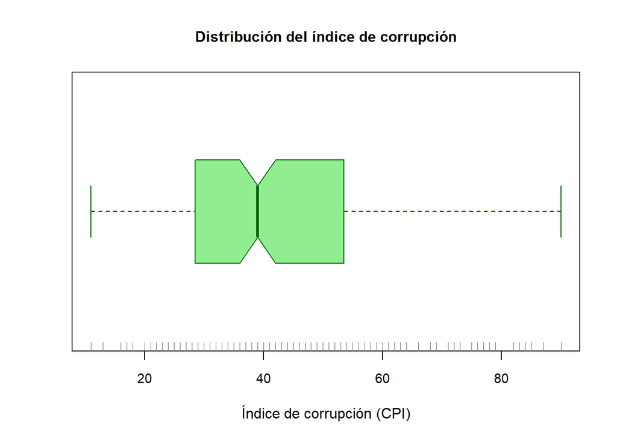

```r
boxplot(
  DATA$corrupcion,
  horizontal = TRUE,
  main = "Distribución del índice de corrupción",
  xlab  = "Índice de corrupción (CPI)",
  col = "lightgreen",     # color de la caja
  border = "darkgreen",   # borde
  notch = TRUE,           # hendidura en la mediana
  outline = TRUE,         # muestra outliers
  cex.axis = 0.9,
  cex.main = 1
)

# Rug para ver la concentración de valores
rug(DATA$corrupcion, col = "gray40")
```

#Variable de control: población

```r
pob_desc <- data.frame(
  Variable = "Población (habitantes)",
  N       = sum(!is.na(DATA$poblacion)),
  Min     = min(DATA$poblacion, na.rm = TRUE),
  Q1      = as.numeric(quantile(DATA$poblacion, 0.25, na.rm = TRUE)),  # sin "25%"
  Mediana = median(DATA$poblacion, na.rm = TRUE),
  Media   = mean(DATA$poblacion, na.rm = TRUE),
  Q3      = as.numeric(quantile(DATA$poblacion, 0.75, na.rm = TRUE)),  # sin "75%"
  Max     = max(DATA$poblacion, na.rm = TRUE),
  SD      = sd(DATA$poblacion, na.rm = TRUE)
)

knitr::kable(
  pob_desc,
  digits = 2,
  row.names = FALSE,   # oculta nombres de fila
  caption = "Descripción estadística de la variable de control: población"
)
```

Descripción estadística de la variable de control: población

| Variable | N | Min | Q1 | Mediana | Media | Q3 | Max | SD |
| --- | --- | --- | --- | --- | --- | --- | --- | --- |
| Población (habitantes) | 171 | 119773 | 3429236 | 10536632 | 46317625 | 34485958 | 1438069596 | 158893269 |

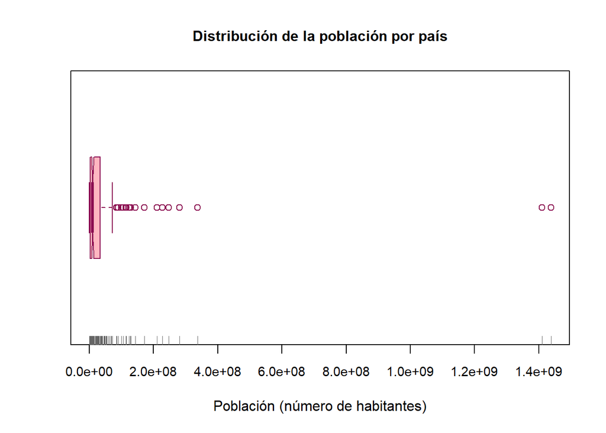

```r
boxplot(
  DATA$poblacion,
  horizontal = TRUE,
  main = "Distribución de la población por país",
  xlab  = "Población (número de habitantes)",
  col = "lightpink",     # color de la caja
  border = "deeppink4",  # color del borde
  notch = TRUE,          # hendidura en la mediana
  outline = TRUE,        # muestra outliers
  cex.axis = 0.9,
  cex.main = 1
)

# Rug para ver la concentración de países en el eje
rug(DATA$poblacion, col = "gray40")
```

#Interpretación El boxplot de población evidencia una distribución fuertemente asimétrica a la derecha. La mayor parte de los países se concentra en valores relativamente bajos de población (la caja está muy cercana al origen), mientras que los bigotes y varios puntos individuales se extienden hacia valores muy elevados. En particular, se observan algunos países con poblaciones extremadamente grandes que aparecen como valores atípicos respecto al resto de la muestra.

Esta configuración indica una alta dispersión en el tamaño demográfico de los países: la mayoría son de población moderada, pero unos pocos casos muy poblados “arrastran” la distribución hacia la derecha. Por ello, resulta pertinente incluir la población como variable de control, para evitar que estas diferencias en tamaño distorsionen la relación entre las demás variables y las incautaciones de droga.

```r
reg1 = lm(kilos_totales ~ democracia + poblacion, data = DATA)
summary(reg1)
```

```
##
## Call:
## lm(formula = kilos_totales ~ democracia + poblacion, data = DATA)
##
## Residuals:
##      Min       1Q   Median       3Q      Max
## -1621638  -343594  -245293  -172859  8814220
##
## Coefficients:
##               Estimate Std. Error t value Pr(>|t|)
## (Intercept)  4.873e+05  3.225e+05   1.511    0.134
## democracia  -3.280e+05  5.121e+05  -0.641    0.523
## poblacion    8.364e-04  6.427e-04   1.301    0.196
##
## Residual standard error: 1290000 on 112 degrees of freedom
##   (56 observations deleted due to missingness)
## Multiple R-squared:  0.02182,    Adjusted R-squared:  0.004355
## F-statistic: 1.249 on 2 and 112 DF,  p-value: 0.2907
```

```r
library(modelsummary)
```

```r
model1=list('TABLA (I)'=reg1)
modelsummary(model1, title = "Regresion: modelo 1",
             stars = TRUE,
             output = "kableExtra")
```

Regresion: modelo 1

|  | &nbsp;TABLA (I) |
| --- | --- |
| (Intercept) | 487273.378 |
|  | (322540.253) |
| democracia | -328022.714 |
|  | (512131.531) |
| poblacion | 0.001 |
|  | (0.001) |
| Num.Obs. | 115 |
| R2 | 0.022 |
| R2 Adj. | 0.004 |
| AIC | 3567.5 |
| BIC | 3578.5 |
| Log.Lik. | -1779.737 |
| RMSE | 1273185.16 |

+ p < 0.1, * p < 0.05, ** p < 0.01, *** p < 0.001

```r
reg2 = lm(kilos_totales ~ democracia+ corrupcion+ poblacion, data = DATA)
summary(reg2)
```

```
##
## Call:
## lm(formula = kilos_totales ~ democracia + corrupcion + poblacion,
##     data = DATA)
##
## Residuals:
##      Min       1Q   Median       3Q      Max
## -1223676  -454991  -277445   106493  8332844
##
## Coefficients:
##               Estimate Std. Error t value Pr(>|t|)
## (Intercept)  7.686e+05  3.294e+05   2.333   0.0214 *
## democracia   1.232e+06  7.516e+05   1.639   0.1041
## corrupcion  -2.570e+04  9.285e+03  -2.768   0.0066 **
## poblacion    1.038e-03  6.287e-04   1.652   0.1014
## ---
## Signif. codes:  0 '***' 0.001 '**' 0.01 '*' 0.05 '.' 0.1 ' ' 1
##
## Residual standard error: 1253000 on 111 degrees of freedom
##   (56 observations deleted due to missingness)
## Multiple R-squared:  0.085,  Adjusted R-squared:  0.06027
## F-statistic: 3.437 on 3 and 111 DF,  p-value: 0.0194
```

```r
library(modelsummary)
model2=list('apropiacion (II)'=reg2)
modelsummary(model2, title = "Regresion: modelo 2",
             stars = TRUE,
             output = "kableExtra")
```

Regresion: modelo 2

|  | &nbsp;apropiacion (II) |
| --- | --- |
| (Intercept) | 768612.874* |
|  | (329420.226) |
| democracia | 1231562.466 |
|  | (751609.944) |
| corrupcion | -25704.937** |
|  | (9285.152) |
| poblacion | 0.001 |
|  | (0.001) |
| Num.Obs. | 115 |
| R2 | 0.085 |
| R2 Adj. | 0.060 |
| AIC | 3561.8 |
| BIC | 3575.5 |
| Log.Lik. | -1775.898 |
| RMSE | 1231384.21 |

+ p < 0.1, * p < 0.05, ** p < 0.01, *** p < 0.001

```r
unique(DATA$Ningresos)
```

```
## [1] "Países de ingreso bajo"         "Ingreso mediano alto"
## [3] "Países de ingreso mediano bajo" "Ingreso alto"
## [5] "No clasificado"
```

```r
DATA$`Ningresos` <- factor(DATA$`Ningresos`,                   levels = c("Países de ingreso bajo", "Ingreso mediano alto", "Países de ingreso mediano bajo","Ingreso alto"),labels = c(1, 2, 3,4))
```

```r
reg3 = lm(kilos_totales ~ democracia+ corrupcion+ poblacion+ Ningresos, data = DATA)
summary(reg3)
```

```
##
## Call:
## lm(formula = kilos_totales ~ democracia + corrupcion + poblacion +
##     Ningresos, data = DATA)
##
## Residuals:
##      Min       1Q   Median       3Q      Max
## -1205697  -468497  -281268   104454  8290576
##
## Coefficients:
##               Estimate Std. Error t value Pr(>|t|)
## (Intercept)  5.979e+05  4.752e+05   1.258   0.2111
## democracia   1.260e+06  8.316e+05   1.515   0.1327
## corrupcion  -2.491e+04  1.147e+04  -2.172   0.0321 *
## poblacion    9.930e-04  6.419e-04   1.547   0.1248
## Ningresos2   1.811e+05  4.283e+05   0.423   0.6732
## Ningresos3   1.940e+05  4.146e+05   0.468   0.6408
## Ningresos4   7.169e+04  5.990e+05   0.120   0.9049
## ---
## Signif. codes:  0 '***' 0.001 '**' 0.01 '*' 0.05 '.' 0.1 ' ' 1
##
## Residual standard error: 1269000 on 108 degrees of freedom
##   (56 observations deleted due to missingness)
## Multiple R-squared:  0.08771,    Adjusted R-squared:  0.03703
## F-statistic: 1.731 on 6 and 108 DF,  p-value: 0.1207
```

```r
library(modelsummary)
model3=list('apropiacion (II)'=reg3)
modelsummary(model3, title = "Regresion: modelo 3",
             stars = TRUE,
             output = "kableExtra")
```

Regresion: modelo 3

|  | &nbsp;apropiacion (II) |
| --- | --- |
| (Intercept) | 597873.937 |
|  | (475236.206) |
| democracia | 1259930.321 |
|  | (831624.493) |
| corrupcion | -24905.733* |
|  | (11468.073) |
| poblacion | 0.001 |
|  | (0.001) |
| Ningresos2 | 181121.298 |
|  | (428253.870) |
| Ningresos3 | 193988.750 |
|  | (414611.881) |
| Ningresos4 | 71691.853 |
|  | (598965.388) |
| Num.Obs. | 115 |
| R2 | 0.088 |
| R2 Adj. | 0.037 |
| AIC | 3567.5 |
| BIC | 3589.4 |
| Log.Lik. | -1775.727 |
| RMSE | 1229558.66 |

+ p < 0.1, * p < 0.05, ** p < 0.01, *** p < 0.001

```r
reg_st = lm(scale(kilos_totales) ~ scale(democracia)+scale(corrupcion) + scale(poblacion) , data = DATA)
summary(reg_st)
```

```
##
## Call:
## lm(formula = scale(kilos_totales) ~ scale(democracia) + scale(corrupcion) +
##     scale(poblacion), data = DATA)
##
## Residuals:
##     Min      1Q  Median      3Q     Max
## -0.9464 -0.3519 -0.2146  0.0824  6.4449
##
## Coefficients:
##                   Estimate Std. Error t value Pr(>|t|)
## (Intercept)       -0.00997    0.09449  -0.106   0.9162
## scale(democracia)  0.24903    0.15198   1.639   0.1041
## scale(corrupcion) -0.37238    0.13451  -2.768   0.0066 **
## scale(poblacion)   0.12761    0.07726   1.652   0.1014
## ---
## Signif. codes:  0 '***' 0.001 '**' 0.01 '*' 0.05 '.' 0.1 ' ' 1
##
## Residual standard error: 0.9694 on 111 degrees of freedom
##   (56 observations deleted due to missingness)
## Multiple R-squared:  0.085,  Adjusted R-squared:  0.06027
## F-statistic: 3.437 on 3 and 111 DF,  p-value: 0.0194
```

```r
modelo_st=list('Voto estandarizado' = reg_st)
modelsummary(modelo_st, title = "Regresion: modelo con \ncoeficientes estandarizados",
             stars = TRUE,
             output = "kableExtra")
```

Regresion: modelo con coeficientes estandarizados

|  | &nbsp;Voto estandarizado |
| --- | --- |
| (Intercept) | -0.010 |
|  | (0.094) |
| scale(democracia) | 0.249 |
|  | (0.152) |
| scale(corrupcion) | -0.372** |
|  | (0.135) |
| scale(poblacion) | 0.128 |
|  | (0.077) |
| Num.Obs. | 115 |
| R2 | 0.085 |
| R2 Adj. | 0.060 |
| AIC | 325.1 |
| BIC | 338.9 |
| Log.Lik. | -157.568 |
| F | 3.437 |
| RMSE | 0.95 |

+ p < 0.1, * p < 0.05, ** p < 0.01, *** p < 0.001

#LINEALIDAD

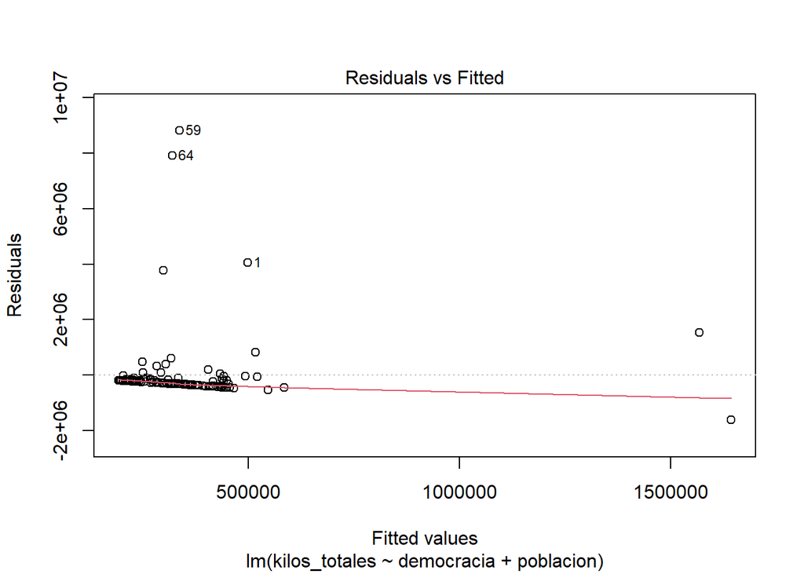

```r
plot(reg1,1)
```

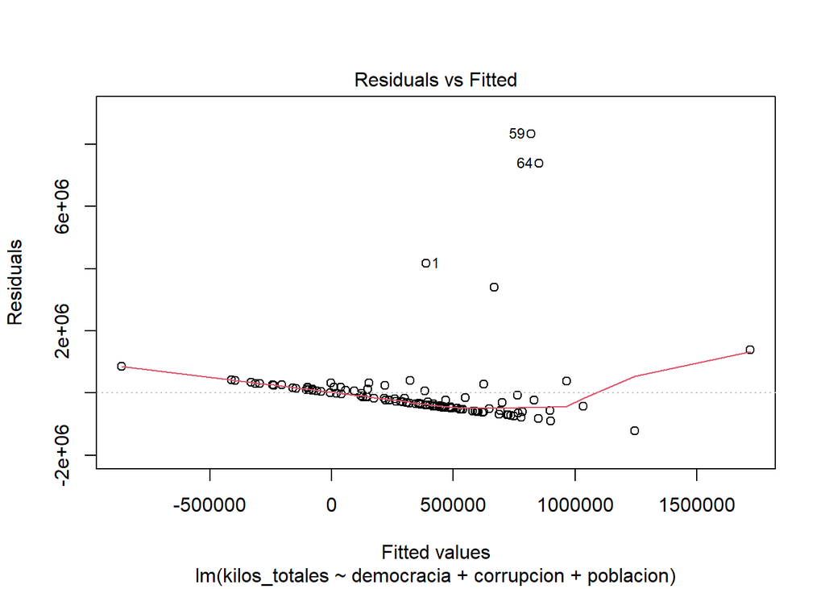

```r
plot(reg2, 1)
```

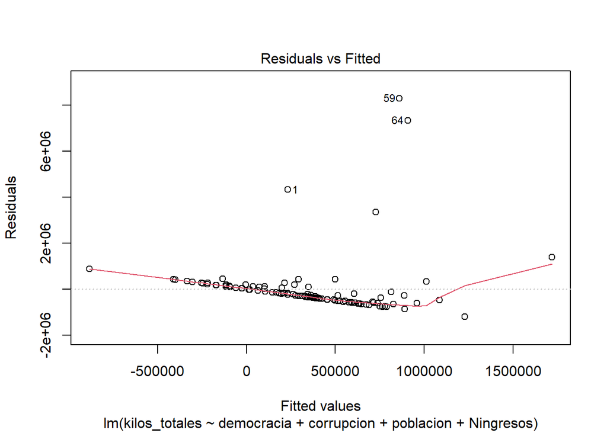

```r
plot(reg3, 1)
```

```r
mean(reg1$residuals)
```

```
## [1] 1.630541e-10
```

```r
mean(reg2$residuals)
```

```
## [1] -3.823041e-11
```

```r
mean(reg3$residuals)
```

```
## [1] 7.058371e-11
```

#HOMOCEDASTICIDAAD

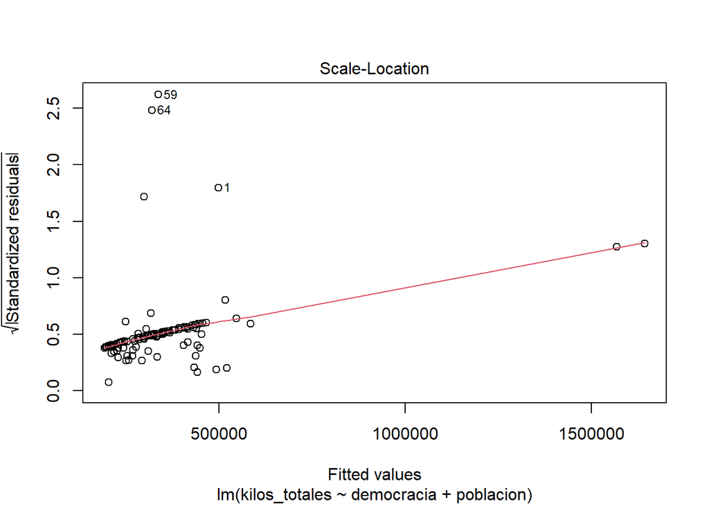

```r
plot(reg1, 3)
```

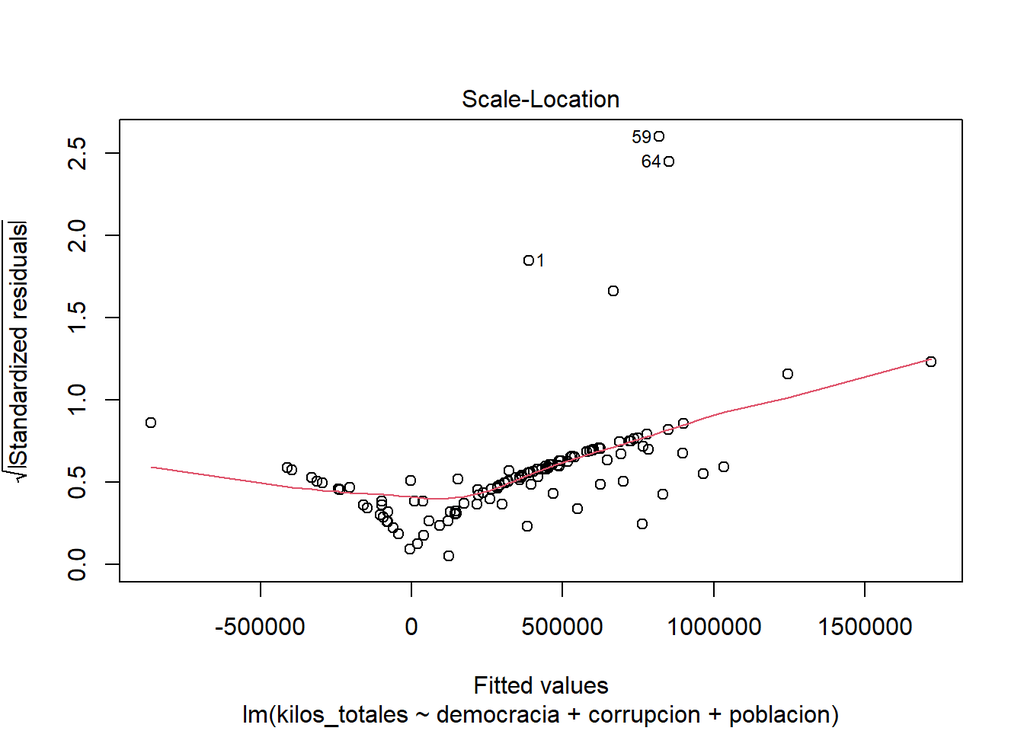

```r
plot(reg2, 3)
```

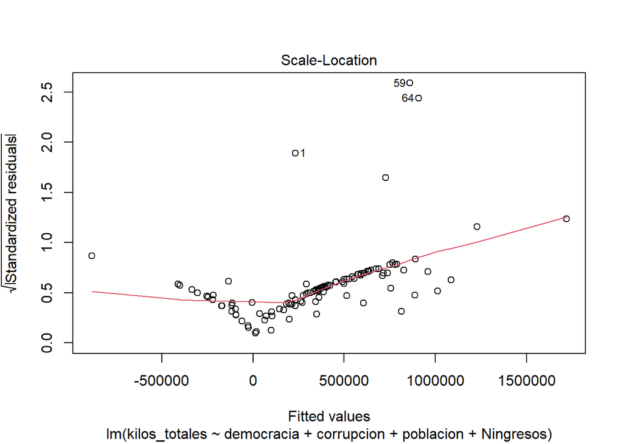

```r
plot(reg3, 3)
```

```r
library(lmtest)
bptest(reg1)
```

```
##
##  studentized Breusch-Pagan test
##
## data:  reg1
## BP = 0.4172, df = 2, p-value = 0.8117
```

```r
bptest(reg2)
```

```
##
##  studentized Breusch-Pagan test
##
## data:  reg2
## BP = 5.8725, df = 3, p-value = 0.118
```

```r
bptest(reg3)
```

```
##
##  studentized Breusch-Pagan test
##
## data:  reg3
## BP = 6.4857, df = 6, p-value = 0.371
```

```r
shapiro.test(reg1$residuals)
```

```
##
##  Shapiro-Wilk normality test
##
## data:  reg1$residuals
## W = 0.32187, p-value < 2.2e-16
```

```r
shapiro.test(reg2$residuals)
```

```
##
##  Shapiro-Wilk normality test
##
## data:  reg2$residuals
## W = 0.4405, p-value < 2.2e-16
```

```r
shapiro.test(reg3$residuals)
```

```
##
##  Shapiro-Wilk normality test
##
## data:  reg3$residuals
## W = 0.44186, p-value < 2.2e-16
```

#NO MULTICOLINEALIDAD

```r
library(DescTools)
VIF(reg1)
```

```
## democracia  poblacion
##   1.035584   1.035584
```

```r
VIF(reg2)
```

```
## democracia corrupcion  poblacion
##   2.363242   2.291007   1.049718
```

```r
VIF(reg3)
```

```
##                GVIF Df GVIF^(1/(2*Df))
## democracia 2.823366  1        1.680287
## corrupcion 3.410505  1        1.846755
## poblacion  1.067824  1        1.033355
## Ningresos  3.618314  3        1.239037
```

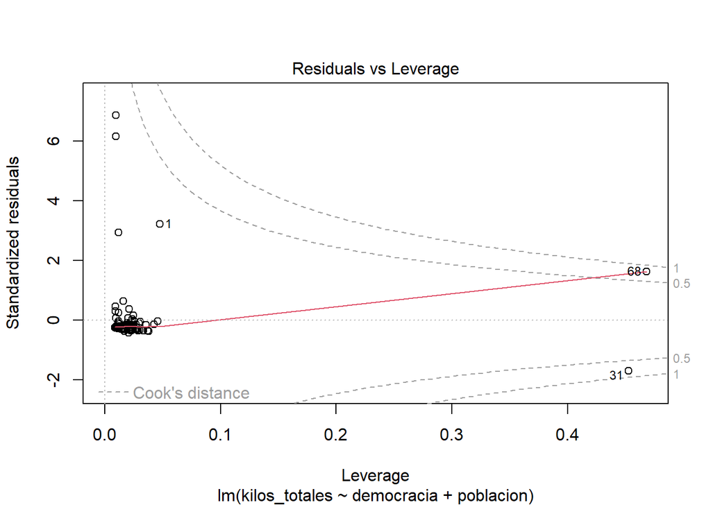

```r
plot(reg1, 5)
```

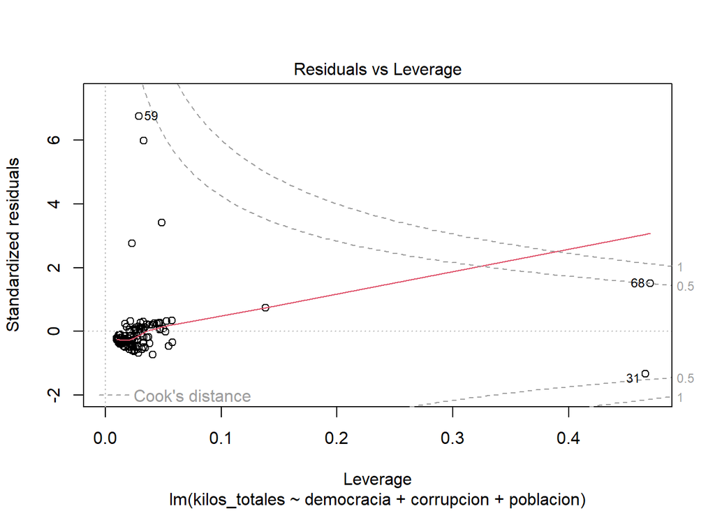

```r
plot(reg2, 5)
```

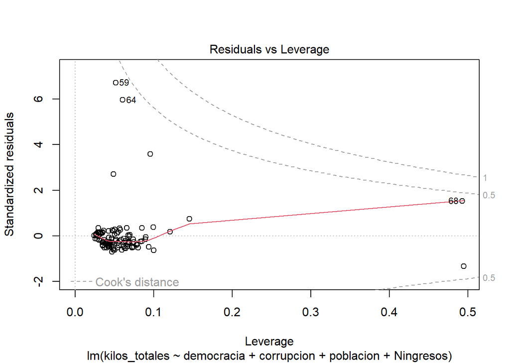

```r
plot(reg3, 5)
```

```r
check = as.data.frame(influence.measures(reg1)$is.inf)
check[check$cook.d & check$hat,]
```

```
##    dfb.1_ dfb.dmcr dfb.pblc dffit cov.r cook.d  hat
## 31  FALSE    FALSE     TRUE  TRUE  TRUE   TRUE TRUE
```

```r
unique(DATA$Ningresos)
```

```
## [1] 1    2    3    4    <NA>
## Levels: 1 2 3 4
```

```r
DATA$Ningresos <- factor(DATA$Ningresos,                   levels = c("1" , "2", "3", "4" ),
                         labels = c(1, 1, 2,2))
```

```r
DATA$Ningresos[DATA$Ningresos == "no clasifica"] <- NA
### first hypothesis
h1=formula(Ningresos~kilos_totales)

#regression
rlog1=glm(h1, data=DATA,family = binomial)
modelrl=list('Drogas por nivel de ingresos'=rlog1)
summary(rlog1)
```

```
##
## Call:
## glm(formula = h1, family = binomial, data = DATA)
##
## Coefficients:
##                 Estimate Std. Error z value Pr(>|z|)
## (Intercept)    4.958e-01  1.990e-01   2.491   0.0127 *
## kilos_totales -1.519e-07  1.543e-07  -0.985   0.3249
## ---
## Signif. codes:  0 '***' 0.001 '**' 0.01 '*' 0.05 '.' 0.1 ' ' 1
##
## (Dispersion parameter for binomial family taken to be 1)
##
##     Null deviance: 153.95  on 114  degrees of freedom
## Residual deviance: 152.90  on 113  degrees of freedom
##   (56 observations deleted due to missingness)
## AIC: 156.9
##
## Number of Fisher Scoring iterations: 4
```

```r
#f <- function(x) format(x, digits = 4, scientific = FALSE)
modelsummary(modelrl,
             title = "Regresión Logística",
             stars = TRUE,
             output = "kableExtra")
```

Regresión Logística

|  | Drogas por nivel de ingresos |
| --- | --- |
| (Intercept) | 0.496* |
|  | (0.199) |
| kilos_totales | -0.000 |
|  | (0.000) |
| Num.Obs. | 115 |
| AIC | 156.9 |
| BIC | 162.4 |
| Log.Lik. | -76.450 |
| RMSE | 0.49 |

+ p < 0.1, * p < 0.05, ** p < 0.01, *** p < 0.001

```r
h1=formula(Ningresos ~ kilos_totales + poblacion)
h2=formula(Ningresos ~ kilos_totales+democracia + poblacion)
h3=formula(Ningresos ~ kilos_totales+democracia+corrupcion+ poblacion)
```

```r
rlog1=glm(h1, data=DATA,family = binomial)
modelrl=list('Drogas por nivel de ingresos'=rlog1)
summary(rlog1)
```

```
##
## Call:
## glm(formula = h1, family = binomial, data = DATA)
##
## Coefficients:
##                 Estimate Std. Error z value Pr(>|z|)
## (Intercept)    5.078e-01  2.055e-01   2.471   0.0135 *
## kilos_totales -1.465e-07  1.548e-07  -0.947   0.3438
## poblacion     -2.378e-10  9.980e-10  -0.238   0.8116
## ---
## Signif. codes:  0 '***' 0.001 '**' 0.01 '*' 0.05 '.' 0.1 ' ' 1
##
## (Dispersion parameter for binomial family taken to be 1)
##
##     Null deviance: 153.95  on 114  degrees of freedom
## Residual deviance: 152.84  on 112  degrees of freedom
##   (56 observations deleted due to missingness)
## AIC: 158.84
##
## Number of Fisher Scoring iterations: 4
```

```r
rlog2=glm(h2, data=DATA,family = binomial)
modelrl=list('Drogas por nivel de ingresos'=rlog2)
summary(rlog2)
```

```
##
## Call:
## glm(formula = h2, family = binomial, data = DATA)
##
## Coefficients:
##                 Estimate Std. Error z value Pr(>|z|)
## (Intercept)   -1.432e+00  5.512e-01  -2.598  0.00939 **
## kilos_totales -1.245e-07  1.588e-07  -0.784  0.43302
## democracia     3.446e+00  9.264e-01   3.719  0.00020 ***
## poblacion      5.039e-10  1.033e-09   0.488  0.62581
## ---
## Signif. codes:  0 '***' 0.001 '**' 0.01 '*' 0.05 '.' 0.1 ' ' 1
##
## (Dispersion parameter for binomial family taken to be 1)
##
##     Null deviance: 153.95  on 114  degrees of freedom
## Residual deviance: 137.10  on 111  degrees of freedom
##   (56 observations deleted due to missingness)
## AIC: 145.1
##
## Number of Fisher Scoring iterations: 4
```

```r
rlog3=glm(h3, data=DATA,family = binomial)
modelrl=list('Drogas por nivel de ingresos'=rlog3)
summary(rlog3)
```

```
##
## Call:
## glm(formula = h3, family = binomial, data = DATA)
##
## Coefficients:
##                 Estimate Std. Error z value Pr(>|z|)
## (Intercept)   -2.725e+00  7.323e-01  -3.721 0.000199 ***
## kilos_totales  5.423e-08  1.610e-07   0.337 0.736170
## democracia    -3.027e-01  1.378e+00  -0.220 0.826112
## corrupcion     7.899e-02  2.319e-02   3.407 0.000657 ***
## poblacion     -2.446e-10  1.048e-09  -0.233 0.815534
## ---
## Signif. codes:  0 '***' 0.001 '**' 0.01 '*' 0.05 '.' 0.1 ' ' 1
##
## (Dispersion parameter for binomial family taken to be 1)
##
##     Null deviance: 153.95  on 114  degrees of freedom
## Residual deviance: 121.94  on 110  degrees of freedom
##   (56 observations deleted due to missingness)
## AIC: 131.94
##
## Number of Fisher Scoring iterations: 5
```

```r
modelsrl=list('Adhesión (I)'=rlog1,
             'Adhesión (II)'=rlog2,
             'Adhesión (III)'=rlog3)

# formato creado para modelsummary
formatoNumero = function(x) format(x, digits = 4, scientific = FALSE)
modelsummary(modelsrl,
             fmt=formatoNumero, # usa función que creé antes
             exponentiate = T, # coeficientes sin logaritmo
             statistic = 'conf.int', # mostrar ICs
             title = "Regresión Logísticas (Coeficientes Exponenciados)",
             stars = TRUE,
             output = "kableExtra")
```

Regresión Logísticas (Coeficientes Exponenciados)

|  | &nbsp;Adhesión (I) | &nbsp;Adhesión (II) | &nbsp;Adhesión (III) |
| --- | --- | --- | --- |
| (Intercept) | 1.662* | 0.2389** | 0.06557*** |
|  | [1.116, 2.505] | [0.07781, 0.6853] | [0.01396, 0.2533] |
| kilos_totales | 1.000 | 1.0000 | 1.00000 |
|  | [1.000, 1.000] | [1.00000, 1.0000] | [1.00000, 1.0000] |
| poblacion | 1.000 | 1.0000 | 1.00000 |
|  | [1.000, 1.000] | [1.00000, 1.0000] | [1.00000, 1.0000] |
| democracia |  | 31.3642*** | 0.73880 |
|  |  | [5.45856, 210.9681] | [0.04728, 10.9389] |
| corrupcion |  |  | 1.08220*** |
|  |  |  | [1.03746, 1.1369] |
| Num.Obs. | 115 | 115 | 115 |
| AIC | 158.8 | 145.1 | 131.9 |
| BIC | 167.1 | 156.1 | 145.7 |
| Log.Lik. | -76.421 | -68.550 | -60.972 |
| RMSE | 0.49 | 0.46 | 0.43 |

+ p < 0.1, * p < 0.05, ** p < 0.01, *** p < 0.001

#CLUSTER

```r
dataClus=DATA[,c(4,6,7,8)]
row.names(dataClus)=DATA$Country
```

```r
dataClus <- na.omit(dataClus)
```

```r
library(cluster)
g.dist = daisy(dataClus, metric="gower")
```

```r
library(factoextra)
```

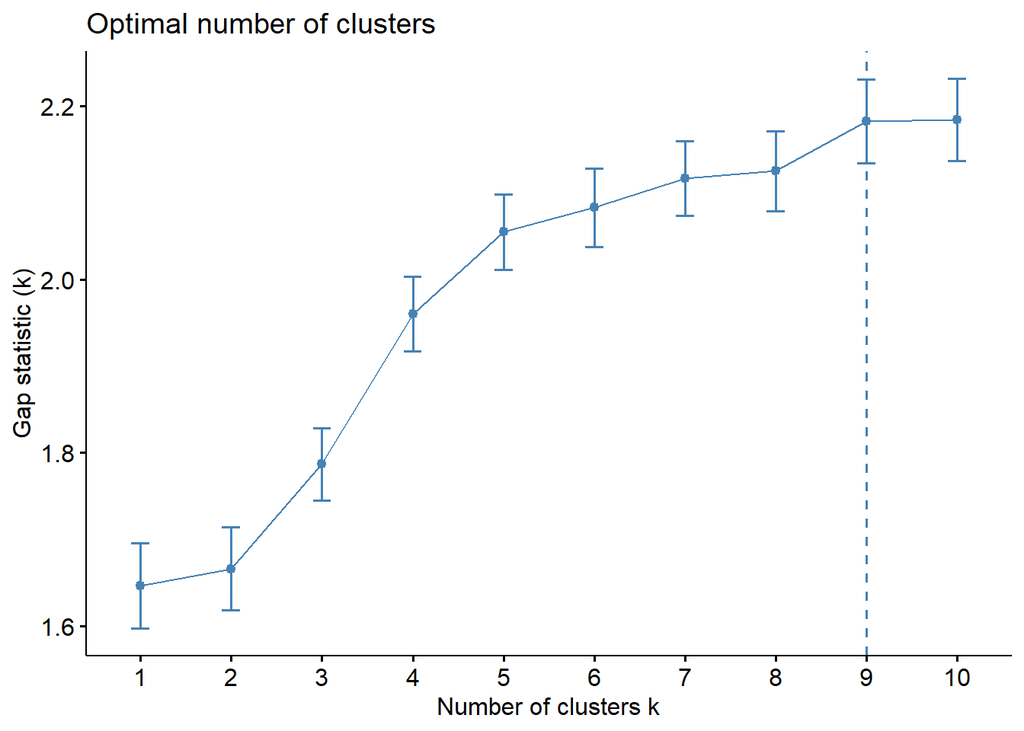

```r
fviz_nbclust(dataClus, pam,diss=g.dist,method = "gap_stat",k.max = 10,verbose = F)
```

```r
library(kableExtra)
set.seed(123)
res.pam=pam(g.dist,9,cluster.only = F)
#nueva columna
dataClus$pam=res.pam$cluster

# ver

head(dataClus,15)%>%kbl()%>%kable_styling()
```

|  | poblacion | democracia | corrupcion | kilos_totales | pam |
| --- | --- | --- | --- | --- | --- |
| Afghanistan | 41454761 | 0.073 | 20 | 4.558808e+06 | 1 |
| Albania | 2745972 | 0.507 | 37 | 2.357985e+03 | 2 |
| Algeria | 46164219 | 0.265 | 36 | 5.004563e+04 | 3 |
| Angola | 36749906 | 0.330 | 33 | 1.399334e+04 | 3 |
| Argentina | 45538401 | 0.838 | 37 | 3.406357e+05 | 4 |
| Armenia | 2964300 | 0.635 | 47 | 3.249862e+01 | 5 |
| Australia | 26652777 | 0.855 | 75 | 4.667940e+04 | 6 |
| Austria | 9131761 | 0.846 | 71 | 5.270837e+03 | 6 |
| Azerbaijan | 10153958 | 0.187 | 23 | 4.389029e+03 | 1 |
| Belarus | 9178298 | 0.157 | 37 | 1.149429e+03 | 3 |
| Belgium | 11787423 | 0.898 | 73 | 1.948574e+05 | 6 |
| Benin | 14111034 | 0.493 | 43 | 7.668199e+03 | 2 |
| Bhutan | 786385 | 0.540 | 68 | 1.977725e+02 | 5 |
| Bosnia and Herzegovina | 3185073 | 0.504 | 35 | 1.314814e+03 | 2 |
| Botswana | 2480244 | 0.556 | 59 | 1.361430e+03 | 5 |

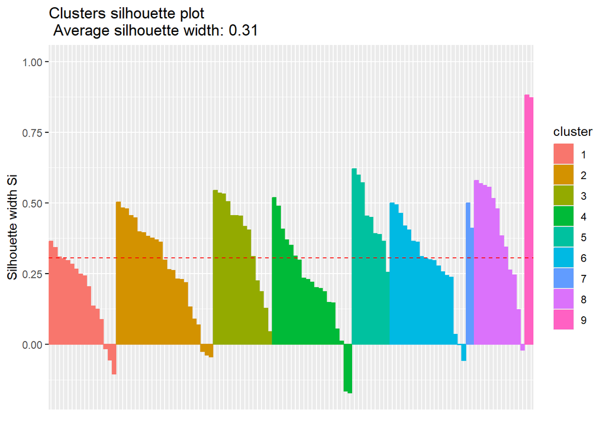

```r
fviz_silhouette(res.pam,print.summary = F)
```

```r
silPAM=data.frame(res.pam$silinfo$widths)
silPAM$country=row.names(silPAM)
poorPAM=silPAM[silPAM$sil_width<0,'country']%>%sort()
poorPAM
```

```
##  [1] "Australia"     "Benin"         "Canada"        "El Salvador"
##  [5] "Guinea-Bissau" "Mali"          "Niger"         "Pakistan"
##  [9] "Senegal"       "Singapore"     "Slovakia"
```

```r
aggregate(.~ pam, data=dataClus,mean)
```

```
##   pam  poblacion democracia corrupcion kilos_totales
## 1   1   38267469  0.2658750   23.18750     312604.28
## 2   2   44817311  0.5065217   33.52174     179567.06
## 3   3   32373572  0.2540714   36.07143     129168.17
## 4   4   26746235  0.7333158   43.26316     318150.22
## 5   5    9623081  0.5661111   53.00000      31516.09
## 6   6   47004365  0.8403889   67.27778     119848.73
## 7   7 1424389798  0.2235000   40.50000    1560867.63
## 8   8   13063432  0.8395833   81.75000      18260.01
## 9   9   14384845  0.5215000   23.00000    8692696.37
```

```r
original=aggregate(.~ pam, data=dataClus,mean)
original[order(original$poblacion),]
```

```
##   pam  poblacion democracia corrupcion kilos_totales
## 5   5    9623081  0.5661111   53.00000      31516.09
## 8   8   13063432  0.8395833   81.75000      18260.01
## 9   9   14384845  0.5215000   23.00000    8692696.37
## 4   4   26746235  0.7333158   43.26316     318150.22
## 3   3   32373572  0.2540714   36.07143     129168.17
## 1   1   38267469  0.2658750   23.18750     312604.28
## 2   2   44817311  0.5065217   33.52174     179567.06
## 6   6   47004365  0.8403889   67.27778     119848.73
## 7   7 1424389798  0.2235000   40.50000    1560867.63
```

```r
dataClus$pam=dplyr::recode(dataClus$pam, `5` = 1, `8`=2,`9`=3,`4`=4,`3`=5,`1`=6,`2`=7,`6`=8,`7`=9)
```

```r
length(DATA$country)
```

```
## [1] 0
```

```r
poorPAM
```

```
##  [1] "Australia"     "Benin"         "Canada"        "El Salvador"
##  [5] "Guinea-Bissau" "Mali"          "Niger"         "Pakistan"
##  [9] "Senegal"       "Singapore"     "Slovakia"
```

```r
length(poorPAM)
```

```
## [1] 11
```

```r
dataClus$pam=NULL
```

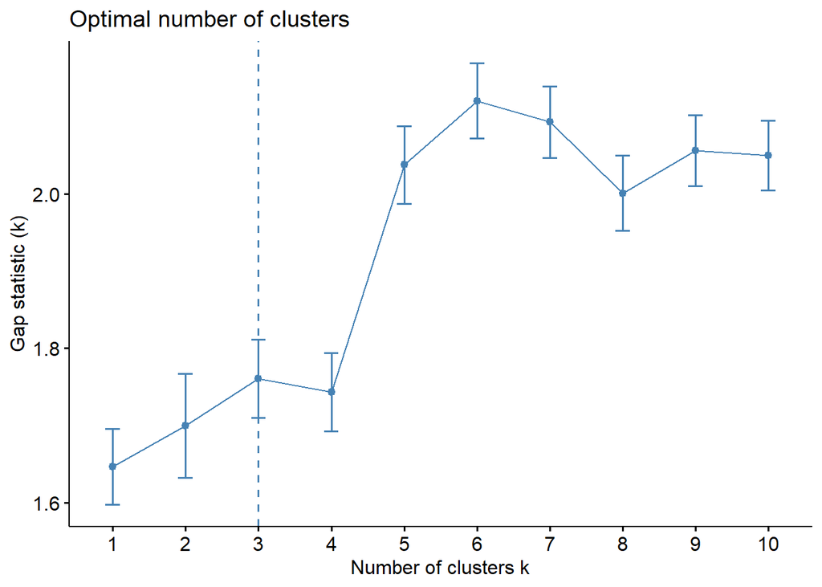

```r
fviz_nbclust(dataClus, hcut,diss=g.dist,method = "gap_stat",k.max = 10,verbose = F,hc_func = "agnes")
```

```r
set.seed(123)
library(factoextra)
res.agnes<- hcut(g.dist, k = 3,hc_func='agnes',hc_method = "ward.D")
dataClus$agnes=res.agnes$cluster
# ver

head(dataClus,15)%>%kbl()%>%kable_styling()
```

|  | poblacion | democracia | corrupcion | kilos_totales | agnes |
| --- | --- | --- | --- | --- | --- |
| Afghanistan | 41454761 | 0.073 | 20 | 4.558808e+06 | 1 |
| Albania | 2745972 | 0.507 | 37 | 2.357985e+03 | 1 |
| Algeria | 46164219 | 0.265 | 36 | 5.004563e+04 | 1 |
| Angola | 36749906 | 0.330 | 33 | 1.399334e+04 | 1 |
| Argentina | 45538401 | 0.838 | 37 | 3.406357e+05 | 2 |
| Armenia | 2964300 | 0.635 | 47 | 3.249862e+01 | 2 |
| Australia | 26652777 | 0.855 | 75 | 4.667940e+04 | 3 |
| Austria | 9131761 | 0.846 | 71 | 5.270837e+03 | 3 |
| Azerbaijan | 10153958 | 0.187 | 23 | 4.389029e+03 | 1 |
| Belarus | 9178298 | 0.157 | 37 | 1.149429e+03 | 1 |
| Belgium | 11787423 | 0.898 | 73 | 1.948574e+05 | 3 |
| Benin | 14111034 | 0.493 | 43 | 7.668199e+03 | 1 |
| Bhutan | 786385 | 0.540 | 68 | 1.977725e+02 | 2 |
| Bosnia and Herzegovina | 3185073 | 0.504 | 35 | 1.314814e+03 | 1 |
| Botswana | 2480244 | 0.556 | 59 | 1.361430e+03 | 2 |

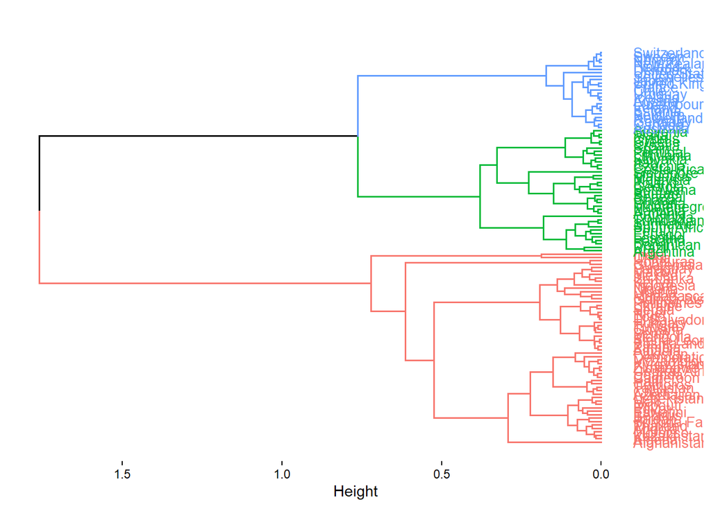

```r
# Visualize
fviz_dend(res.agnes, cex = 0.7, horiz = T,main = "")
```

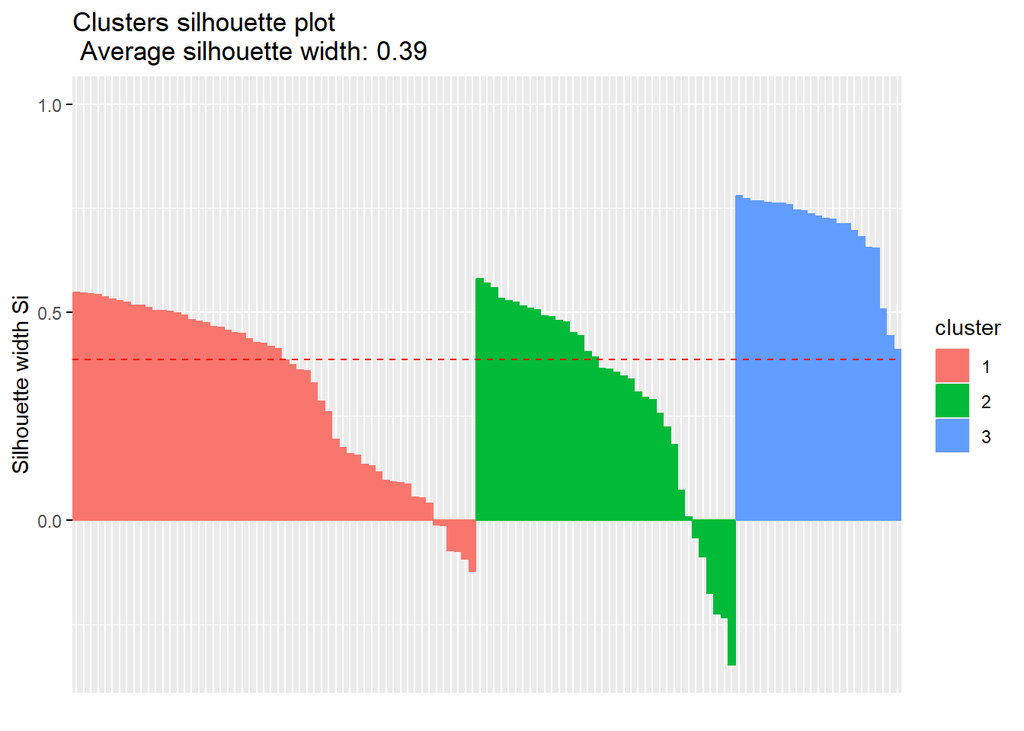

```r
fviz_silhouette(res.agnes,print.summary = F)
```

```r
silAGNES=data.frame(res.agnes$silinfo$widths)
silAGNES$country=row.names(silAGNES)
poorAGNES=silAGNES[silAGNES$sil_width<0,'country']%>%sort()
poorAGNES
```

```
##  [1] "Benin"      "Costa Rica" "Czechia"    "Guyana"     "Liberia"
##  [6] "Lithuania"  "Malawi"     "Portugal"   "Singapore"  "Spain"
## [11] "Sri Lanka"  "Zambia"
```

```r
aggregate(.~ agnes, data=dataClus,mean)
```

```
##   agnes poblacion democracia corrupcion kilos_totales
## 1     1  88497801  0.3627143   31.07143     554686.94
## 2     2  20984573  0.6973056   49.05556     213340.09
## 3     3  37398321  0.8593913   76.47826      61277.28
```

```r
dataClus$agnes=NULL
```

#DIANA

```r
set.seed(123)
res.diana <- hcut(g.dist, k = 4,hc_func='diana')
dataClus$diana=res.diana$cluster
# veamos
head(dataClus,15)%>%kbl%>%kable_styling()
```

|  | poblacion | democracia | corrupcion | kilos_totales | diana |
| --- | --- | --- | --- | --- | --- |
| Afghanistan | 41454761 | 0.073 | 20 | 4.558808e+06 | 1 |
| Albania | 2745972 | 0.507 | 37 | 2.357985e+03 | 2 |
| Algeria | 46164219 | 0.265 | 36 | 5.004563e+04 | 2 |
| Angola | 36749906 | 0.330 | 33 | 1.399334e+04 | 2 |
| Argentina | 45538401 | 0.838 | 37 | 3.406357e+05 | 3 |
| Armenia | 2964300 | 0.635 | 47 | 3.249862e+01 | 2 |
| Australia | 26652777 | 0.855 | 75 | 4.667940e+04 | 3 |
| Austria | 9131761 | 0.846 | 71 | 5.270837e+03 | 3 |
| Azerbaijan | 10153958 | 0.187 | 23 | 4.389029e+03 | 2 |
| Belarus | 9178298 | 0.157 | 37 | 1.149429e+03 | 2 |
| Belgium | 11787423 | 0.898 | 73 | 1.948574e+05 | 3 |
| Benin | 14111034 | 0.493 | 43 | 7.668199e+03 | 2 |
| Bhutan | 786385 | 0.540 | 68 | 1.977725e+02 | 3 |
| Bosnia and Herzegovina | 3185073 | 0.504 | 35 | 1.314814e+03 | 2 |
| Botswana | 2480244 | 0.556 | 59 | 1.361430e+03 | 3 |

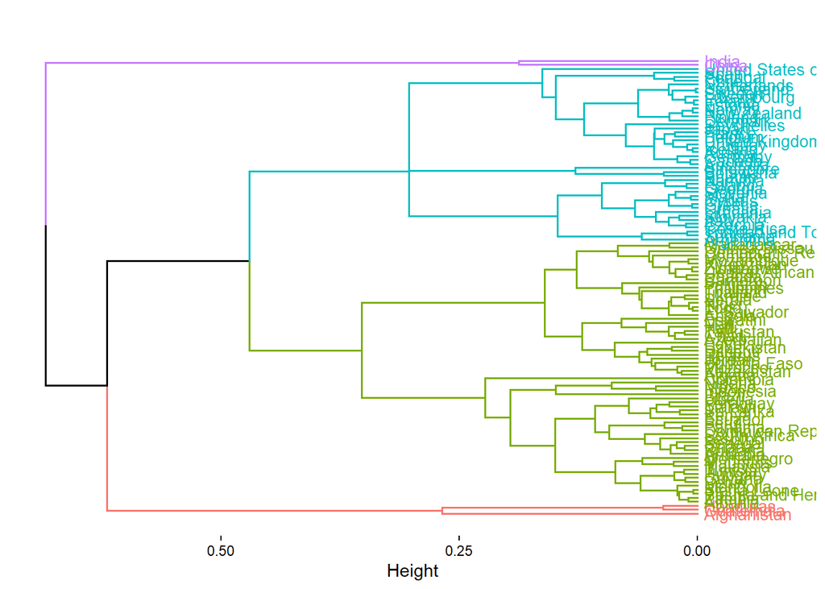

```r
# Visualize
fviz_dend(res.diana, cex = 0.7, horiz = T, main = "")
```

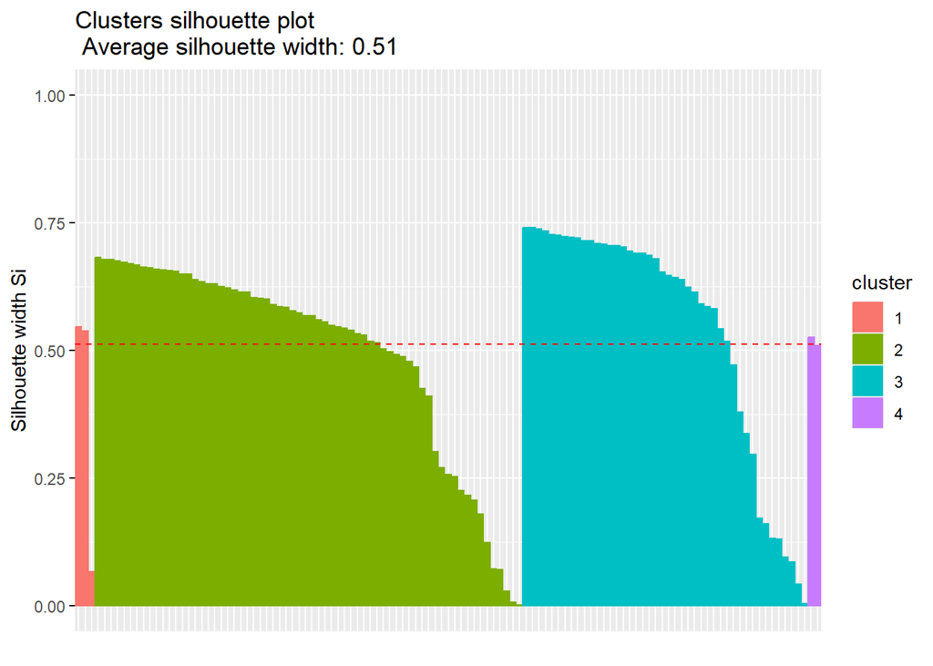

```r
fviz_silhouette(res.diana,print.summary = F)
```

```r
silDIANA=data.frame(res.diana$silinfo$widths)
silDIANA$country=row.names(silDIANA)
poorDIANA=silDIANA[silDIANA$sil_width<0,'country']%>%sort()
poorDIANA
```

```
## character(0)
```